# Starwars community detection

### 1.6.2 Fast greedy community detection

The fast greedy is a simplified version of the previous method. In this case, we can see that the number of communities resulting is 7, where the red one appears to be the larger with 54 out of the 111 characters. This community contains the main characters that we have seen in the previous assignments were the more connected ones like Darth Vader, Qui-Won, Obi-Wan, C-3PO and more. The second largest is the light blue, with 20 less connected characters like Coloneel Dato, Poe, and Jess. The third largest is the blue one with 15 characters and wich includes characters like Chewbacca, Leia, Luke and Han Solo, which recall were some of the characters that had more number of scenes with other characters. The rest of communities have fewer characters with 10, 8, 3, and lastly, 1 which corresponds to Gold Five. Moreover, the modularity of the partition for this method is 0.3962.

```r
Start_time <- Sys.time()
sw.network.fg <- cluster_fast_greedy(sw.network)
sw.network.fg
```

```
## IGRAPH clustering fast greedy, groups: 7, mod: 0.4
## + groups:
##   $`1`
##    [1] "DARTH VADER"          "QUI-GON"              "OBI-WAN"
##    [4] "EMPEROR"              "CAPTAIN PANAKA"       "SIO BIBBLE"
##    [7] "JAR JAR"              "TARPALS"              "BOSS NASS"
##   [10] "PADME"                "RIC OLIE"             "WATTO"
##   [13] "SEBULBA"              "JIRA"                 "SHMI"
##   [16] "KITSTER"              "WALD"                 "FODE/BEED"
##   [19] "GREEDO"               "VALORUM"              "MACE WINDU"
##   [22] "KI-ADI-MUNDI"         "YODA"                 "RABE"
##   [25] "BAIL ORGANA"          "BRAVO TWO"            "BRAVO THREE"
##   + ... omitted several groups/vertices
```

```r
End_time <- Sys.time()

print(paste('Time elapsed: ', (End_time-Start_time)))
```

```
## [1] "Time elapsed:  0.00797915458679199"
```

```r
length(sw.network.fg)
```

```
## [1] 7
```

```r
sizes(sw.network.fg)
```

```
## Community sizes
##  1  2  3  4  5  6  7
## 54 20 10  8 15  3  1
```

```r
membership(sw.network.fg)
```

```
##          DARTH VADER                R2-D2            CHEWBACCA
##                    1                    5                    5
##                 BB-8              QUI-GON          NUTE GUNRAY
##                    2                    1                    3
##                 PK-4                TC-14              OBI-WAN
##                    3                    3                    1
##               DOFINE                 RUNE              TEY HOW
##                    3                    3                    3
##              EMPEROR       CAPTAIN PANAKA           SIO BIBBLE
##                    1                    1                    1
##              JAR JAR              TARPALS            BOSS NASS
##                    1                    1                    1
##                PADME             RIC OLIE                WATTO
##                    1                    1                    1
##              SEBULBA                 JIRA                 SHMI
##                    1                    1                    1
##                C-3PO           DARTH MAUL              KITSTER
##                    5                    3                    1
##                 WALD            FODE/BEED                JABBA
##                    1                    1                    5
##               GREEDO              VALORUM           MACE WINDU
##                    1                    1                    1
##         KI-ADI-MUNDI                 YODA                 RABE
##                    1                    1                    1
##          BAIL ORGANA         GENERAL CEEL            BRAVO TWO
##                    1                    3                    1
##          BRAVO THREE        CAPTAIN TYPHO      SENATOR ASK AAK
##                    1                    1                    1
##         ORN FREE TAA                 SOLA                JOBAL
##                    1                    1                    1
##                RUWEE              TAUN WE              LAMA SU
##                    1                    1                    1
##            BOBA FETT           JANGO FETT                 OWEN
##                    1                    1                    6
##                 BERU               CLIEGG          COUNT DOOKU
##                    6                    6                    1
##              SUN RIT               POGGLE             PLO KOON
##                    3                    3                    1
##             ODD BALL     GENERAL GRIEVOUS             FANG ZAR
##                    1                    1                    1
```

[output cut: 19 more lines]

```
##                    5                    1                    5
##               BOUSHH       ADMIRAL ACKBAR        LOR SAN TEKKA
##                    5                    5                    2
##                  POE             KYLO REN       CAPTAIN PHASMA
##                    2                    2                    2
##                 FINN          UNKAR PLUTT                  REY
##                    2                    2                    2
##          GENERAL HUX    LIEUTENANT MITAKA             BALA-TIK
##                    2                    2                    2
##                SNOKE                  MAZ                 SNAP
##                    2                    2                    2
##      ADMIRAL STATURA            YOLO ZIFF        COLONEL DATOO
##                    2                    2                    2
##            ELLO ASTY                 JESS              NIV LEK
##                    2                    2                    2
```

```r
modularity(sw.network.fg)
```

```
## [1] 0.3962382
```

```r
method.compare[2,1]<- modularity(sw.network.fg)
method.compare[2,2]<- length(sizes(sw.network.fg))
method.compare[2,3]<-(End_time-Start_time)
```

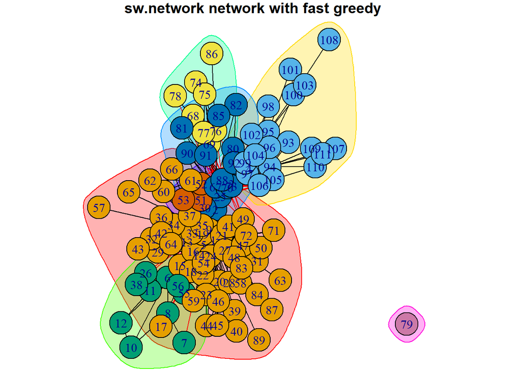

```r
par(mar=c(0,0,1,1))
sw.network.fg <- cluster_fast_greedy(sw.network)
plot(sw.network.fg,
     sw.network,
     vertex.color=membership(sw.network.fg),
     vertex.label=seq(1:111),
     #vertex.label=NA,
     main="sw.network network with fast greedy")
```

### 1.6.3 Louvain community detection

The Louvain community detection method is similar to the optimal modularity but the optimization is done using a hierarchical approach, then this can be used for large networks. In this case, as same as before we obtained that the optimal number of communities is 7 with a modularity of 0.3962 with the same partition as the last method.

```r
Start_time <- Sys.time()
sw.network.lo <- cluster_louvain(sw.network)
sw.network.lo
```

```
## IGRAPH clustering multi level, groups: 7, mod: 0.4
## + groups:
##   $`1`
##    [1] "DARTH VADER"          "QUI-GON"              "OBI-WAN"
##    [4] "EMPEROR"              "CAPTAIN PANAKA"       "SIO BIBBLE"
##    [7] "JAR JAR"              "TARPALS"              "BOSS NASS"
##   [10] "PADME"                "RIC OLIE"             "WATTO"
##   [13] "SEBULBA"              "JIRA"                 "SHMI"
##   [16] "KITSTER"              "WALD"                 "FODE/BEED"
##   [19] "GREEDO"               "VALORUM"              "MACE WINDU"
##   [22] "KI-ADI-MUNDI"         "YODA"                 "RABE"
##   [25] "BAIL ORGANA"          "BRAVO TWO"            "BRAVO THREE"
##   + ... omitted several groups/vertices
```

```r
End_time <- Sys.time()

print(paste('Time elapsed: ', (End_time-Start_time)))
```

```
## [1] "Time elapsed:  0.0139658451080322"
```

```r
method.compare[3,1]<- modularity(sw.network.lo)
method.compare[3,2]<- length(sizes(sw.network.lo))
method.compare[3,3]<-(End_time-Start_time)
```

```r
length(sw.network.lo)
```

```
## [1] 7
```

```r
sizes(sw.network.lo)
```

```
## Community sizes
##  1  2  3  4  5  6  7
## 54  3 10 15  8  1 20
```

```r
membership(sw.network.lo)
```

```
##          DARTH VADER                R2-D2            CHEWBACCA
##                    1                    4                    4
##                 BB-8              QUI-GON          NUTE GUNRAY
##                    7                    1                    3
##                 PK-4                TC-14              OBI-WAN
##                    3                    3                    1
##               DOFINE                 RUNE              TEY HOW
##                    3                    3                    3
##              EMPEROR       CAPTAIN PANAKA           SIO BIBBLE
##                    1                    1                    1
##              JAR JAR              TARPALS            BOSS NASS
##                    1                    1                    1
##                PADME             RIC OLIE                WATTO
##                    1                    1                    1
##              SEBULBA                 JIRA                 SHMI
##                    1                    1                    1
##                C-3PO           DARTH MAUL              KITSTER
##                    4                    3                    1
##                 WALD            FODE/BEED                JABBA
##                    1                    1                    4
##               GREEDO              VALORUM           MACE WINDU
##                    1                    1                    1
##         KI-ADI-MUNDI                 YODA                 RABE
##                    1                    1                    1
##          BAIL ORGANA         GENERAL CEEL            BRAVO TWO
##                    1                    3                    1
##          BRAVO THREE        CAPTAIN TYPHO      SENATOR ASK AAK
##                    1                    1                    1
##         ORN FREE TAA                 SOLA                JOBAL
##                    1                    1                    1
##                RUWEE              TAUN WE              LAMA SU
##                    1                    1                    1
##            BOBA FETT           JANGO FETT                 OWEN
##                    1                    1                    2
##                 BERU               CLIEGG          COUNT DOOKU
##                    2                    2                    1
##              SUN RIT               POGGLE             PLO KOON
##                    3                    3                    1
##             ODD BALL     GENERAL GRIEVOUS             FANG ZAR
##                    1                    1                    1
```

[output cut: 19 more lines]

```
##                    4                    1                    4
##               BOUSHH       ADMIRAL ACKBAR        LOR SAN TEKKA
##                    4                    4                    7
##                  POE             KYLO REN       CAPTAIN PHASMA
##                    7                    7                    7
##                 FINN          UNKAR PLUTT                  REY
##                    7                    7                    7
##          GENERAL HUX    LIEUTENANT MITAKA             BALA-TIK
##                    7                    7                    7
##                SNOKE                  MAZ                 SNAP
##                    7                    7                    7
##      ADMIRAL STATURA            YOLO ZIFF        COLONEL DATOO
##                    7                    7                    7
##            ELLO ASTY                 JESS              NIV LEK
##                    7                    7                    7
```

```r
modularity(sw.network.lo)
```

```
## [1] 0.3962382
```

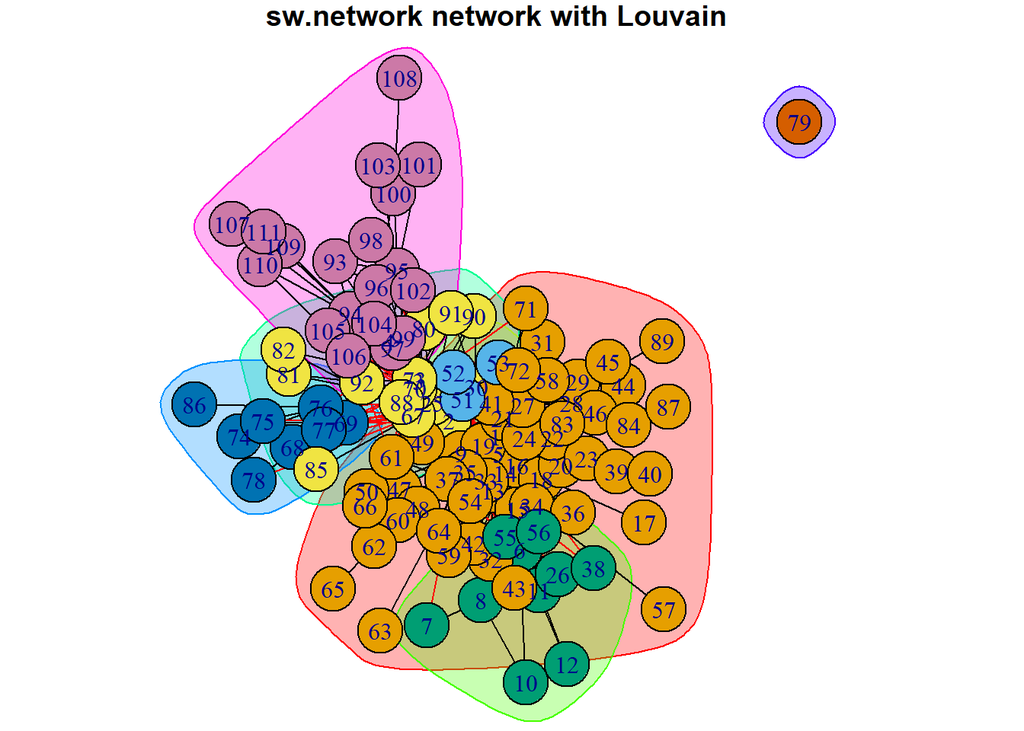

```r
par(mar=c(0,0,1,1))
plot(sw.network.lo,
     sw.network,
     vertex.color=membership(sw.network.fg),
     vertex.label=seq(1:111),
     #vertex.label=NA,
     main="sw.network network with Louvain")
```